# Streaming Service and Data Analysis

*5 May 2021*

# Introduction

Netflix is a streaming service that offers a wide variety of award-winning TV shows, movies, anime, documentaries, and more on thousands of internet-connected devices.

In this project, I will programme a model of Netflix in Python. I create the class `User` to represent subscribers of the streaming service and the class `FavouritePlaylist`, which is a playlist of the user's favourite shows **(Task 1)**. I will also implement a searching algorithm for shows to create a search engine for users **(Task 2)**.

Finally, I will conduct some data analysis on Netflix shows **(Task 3)**. Netflix has more than 4,000 movies and more than 1,900 TV shows from a wide variety of genres. Given such a wide range of shows, I wish to analyse trends in the shows on Netflix.

Specifically, I will use the data to:  
1) Analyse **popular topics** in shows

- Find the most popular topics for all shows of all time
- Find how popular topics have changed over the years (trends)

2) Analyse **cast and directors** of shows

- Find the pairs of actors or actresses that often work together
- Find the pairs of actors/actresses and directors that often work together

3) Find **shows that are most related to one another**. This is useful for creating a recommendation system for users in our streaming service.

### Data Description

In this project, I use the following data:  
`netflix_data`: A csv file of data of all shows on Netflix, from kaggle. For each show, there is information on its

- type: Identifier - A Movie or TV Show
- title: Title of the Movie / Tv Show
- director: Director of the Movie
- cast: Actors involved in the movie / show
- country: Country where the movie / show was produced
- date_added: Date it was added on Netflix
- release_year: Actual Release year of the move / show
- rating: TV Rating of the movie / show
- duration: Total Duration - in minutes or number of seasons
- listed_in: Genre
- description: The summary description

`stopping_words`: A txt file of stopping words to remove when analysing show descriptions, so that we are left with the keywords only

# Task 1: User and Playlist

For this task, I created the class User to represent the subscribers for a streaming service and added the class FavouritePlaylist.  
Code locations:

- `user.py` in the `src` folder
- `favouriteplaylist.py` in the `src` folder

These codes uses code from the following modules:

- `class.py` in the `src` folder
- `playlist.py` in the `src` folder

## 1.1 Demonstrate how User works by creating at least one instance and calling the methods

```python
from user import User
from show import Show
```

Create instance of `User` and some instances of `Show` to test the methods of `User`

```python
user = User('Jack', '2000-02-01')

show_1 = Show('s6881', 'Movie', 'The Smurfs', 'Hank Azaria, Neil Patrick Harris, Jayma Mays, Sofía Vergara, Tim Gunn, Jonathan Winters, Katy Perry, Alan Cumming, Fred Armisen, George Lopez, Anton Yelchin, Kenan Thompson, Jeff Foxworthy, John Oliver, Wolfgang Puck, B.J. Novak, Paul Reubens', '2020', 'PG', '103 min', 'When evil Gargamel tries to capture them, the Smurfs flee their woodland home, pass through a magic portal and find themselves stranded in New York.')
show_2 = Show('s3082', 'TV Show', "It's Okay to Not Be Okay", 'Kim Soo-hyun, Seo Yea-ji, Oh Jung-se, Park Gyu-young, Kim Ju-hun, Kim Chang-wan, Kim Mee-kyung, Kang Ki-doong, Jang Young-nam', '2020', 'TV-MA', '1 Season', "An extraordinary road to emotional healing opens up for an antisocial children's book writer and a selfless psych ward caretaker when they cross paths.")
show_3 = Show('s4837', 'Movie', 'Peter Rabbit', 'James Corden, Domhnall Gleeson, Rose Byrne, Margot Robbie, Daisy Ridley, Elizabeth Debicki, Vauxhall Jermaine, Marianne Jean-Baptiste, Sia, Colin Moody', '2018', 'PG', '95 min', "In this mix of live action and CGI, rascally Peter Rabbit faces a tough new foe in his ongoing battle for the veggies in Mr. McGregor's garden.")
```

**a. Demonstrate the method `add_watch_later`**

```python
user.add_watch_later(show_1)
user.get_watch_later_shows() # To check if the show has been added successfully
```

```
{'The Smurfs': The Smurfs (Movie)}
```

**b. Demonstrate the method `remove_watch_later`**

```python
user.remove_watch_later('The Smurfs')
user.get_watch_later_shows() # To check if the show has been removed successfully
```

```
{}
```

User's Watch Later playlist is empty, which means `show_1` has been removed successfully

**c. Demonstrate the method `play_watch_later`**

```python
# Add shows first to watch_later for playing
user.add_watch_later(show_1)
user.add_watch_later(show_2)
user.add_watch_later(show_3)
```

Scenario 1: Play a specific show from the Watch Later playlist. The show should be removed after it is played.

```python
user.play_watch_later('The Smurfs')
```

```
('Playing the show The Smurfs (103 min)', The Smurfs (Movie))
```

```python
user.get_watch_later_shows() # Check that 'The Smurfs' has been removed after it was played
```

```
{"It's Okay to Not Be Okay": It's Okay to Not Be Okay (TV Show),
 'Peter Rabbit': Peter Rabbit (Movie)}
```

Scenario 2: Do not specify a show title to play. The method should automatically play the first show from the Watch Later playlist.

```python
user.play_watch_later()
```

```
("Playing the show It's Okay to Not Be Okay (1 Season)",
 It's Okay to Not Be Okay (TV Show))
```

```python
user.get_watch_later_shows() # Check that 'The Smurfs' has been removed after it was played
```

```
{'Peter Rabbit': Peter Rabbit (Movie)}
```

**d. Demonstrate the method `add_favourite`**

```python
user.add_favourite(show_1)
user.get_favourite_shows() # To check if the show has been added successfully
```

```
{'The Smurfs': The Smurfs (Movie)}
```

**e. Demonstrate the method `remove_favourite`**

```python
user.remove_favourite('The Smurfs')
user.get_favourite_shows() # To check if the show has been removed successfully
```

```
{}
```

User's Favourite playlist is empty, which means `show_1` has been removed successfully

**f. Demonstrate the method `play_favourite`**

```python
# Add shows first to watch_later for playing
user.add_favourite(show_1)
user.add_favourite(show_2)
user.add_favourite(show_3)
```

Scenario 1: Play a specific show from the Favourite playlist. The show should **not** be removed after it is played.

```python
user.play_favourite('Peter Rabbit')
```

```
('Playing the show Peter Rabbit (95 min)', Peter Rabbit (Movie))
```

```python
user.get_favourite_shows() # Check that 'Peter Rabbit' has not been removed after it was played
```

```
{'The Smurfs': The Smurfs (Movie),
 "It's Okay to Not Be Okay": It's Okay to Not Be Okay (TV Show),
 'Peter Rabbit': Peter Rabbit (Movie)}
```

Scenario 2: Do not specify a show title to play. The method should automatically play a random show.

```python
user.play_favourite()
```

```
('No show has been entered, will play random show using shuffle play',
 ("Playing the show It's Okay to Not Be Okay (1 Season)",
  It's Okay to Not Be Okay (TV Show)))
```

Scenario 3: The show to play in Favourite is also found in the Watch Later playlist. After playing, the show should be removed from the Watch Later playlist, as it has already been watched.

```python
user.add_watch_later(show_1)
user.get_watch_later_shows() # Add the show 'The Smurfs' to Watch Later Playlist
```

```
{'The Smurfs': The Smurfs (Movie)}
```

```python
user.get_favourite_shows()
```

```
{'The Smurfs': The Smurfs (Movie),
 "It's Okay to Not Be Okay": It's Okay to Not Be Okay (TV Show),
 'Peter Rabbit': Peter Rabbit (Movie)}
```

As seen from above, 'The Smurfs' is in both Watch Later and Favourite playlists.

```python
user.play_favourite('The Smurfs')
```

```
('Playing the show The Smurfs (103 min)', The Smurfs (Movie))
```

```python
user.get_watch_later_shows()
```

```
{}
```

The show, 'The Smurfs' is no longer in the Watch Later playlist after being played.

**g. Demonstrate the method `get_history`**

```python
user.get_history()
```

```
['The Smurfs', "It's Okay to Not Be Okay", 'Peter Rabbit', 'The Smurfs']
```

**h. Demonstrate the method `clear_history`**

```python
user.clear_history()
```

```
'Your history has been successfully cleared.'
```

```python
user.get_history() # To check if history is really empty
```

```
[]
```

**i. Demonstrate the method `get_age`**

```python
user.get_age()
```

```
21
```

This is correct, as today is 5 May 2021 and the user entered his birthday as '2000-02-01' (1 Feb 2000).

## 1.2 Testing of `user` with Assertion

```python
# Create another user for testing
user2 = User('Jill', '2003-12-11')

'''Testing methods on User's Watch Later playlist'''
# Test add_watch_later
user2.add_watch_later(show_1) # show_1 is 'The Smurfs'
assert len(user2.get_watch_later_shows()) == 1, f"Add watch later: expected 1 show in the playlist but {len(user2.get_watch_later_shows())} is in the list."

user2.add_watch_later(show_2) # show_2 is "It's Okay to Not Be Okay"
assert len(user2.get_watch_later_shows()) == 2, f"Add watch later: expected 2 shows in the playlist but {len(user2.get_watch_later_shows())} is in the list."

user2.add_watch_later(show_3) # show_3 is "Peter Rabbit"
assert len(user2.get_watch_later_shows()) == 3, f"Add watch later: expected 3 shows in the playlist but {len(user2.get_watch_later_shows())} is in the list."

# Test remove_watch_later
user2.remove_watch_later("It's Okay to Not Be Okay") # I remove show_2
assert len(user2.get_watch_later_shows()) == 2, f"Remove watch later: expected 1 show in the playlist but {len(user2.get_watch_later_shows())} is in the list."

# Test removing a show that is not in the playlist with remove_watch_later
try:
    user2.remove_watch_later("Hi Five")
except KeyError:
    pass
except:
    assert False, f"Remove a show not from Watch Later playlist: expected to raise KeyError but another errortype is raised."
else:
    assert False, f"Remove a show not from Watch Later playlist: expected to raise KeyError but no error is raised."

# Test play_watch_later with no show title specified, the first show in the playlist should be played by default (which is 'The Smurfs')
user2.play_watch_later()
assert len(user2.get_watch_later_shows()) == 1, f"Play watch later: expected 1 show in the playlist but {len(user2.get_watch_later_shows())} is in the list."

# Test play_watch_later with show title specified, check if playlist removes show from Watch Later playlist after playing.
user2.play_watch_later('Peter Rabbit')
assert len(user2.get_watch_later_shows()) == 0, f"Play watch later: expected 0 shows in the playlist but {len(user2.get_watch_later_shows())} is in the list."

# Test play_watch_later with show that is not in playlist
try:
    user2.play_watch_later("Jack and the Beanstalk")
except KeyError:
    pass
except:
    assert False, f"Play a show not in Watch Later playlist: expected to raise KeyError but another errortype is raised."
else:
    assert False, f"Play a show not in Watch Later playlist: expected to raise KeyError but no error is raised."

# Test play_watch_later with no show inside
try:
    user2.play_watch_later()
except IndexError:
    pass
except:
    assert False, f"Play a show from an empty watch later playlist: expected to raise IndexError but another errortype is raised."
else:
    assert False, f"Play a show from an empty watch later playlist: expected to raise IndexError but no error is raised."

'''Testing methods on User's Favourite playlist'''
# Test add_favourite
user2.add_favourite(show_1) # show_1 is 'The Smurfs'
assert len(user2.get_favourite_shows()) == 1, f"Add favourite: expected 1 show in the playlist but {len(user2.get_favourite_shows())} is in the list."

user2.add_favourite(show_2) # show_2 is "It's Okay Not to Be Okay"
assert len(user2.get_favourite_shows()) == 2, f"Add favourite: expected 2 shows in the playlist but {len(user2.get_favourite_shows())} is in the list."

user2.add_favourite(show_3) # show_3 is 'Peter Rabbit'
assert len(user2.get_favourite_shows()) == 3, f"Add favourite: expected 3 shows in the playlist but {len(user2.get_favourite_shows())} is in the list."

# Test remove_favourite
user2.remove_favourite('The Smurfs') # I remove show_1
assert len(user2.get_favourite_shows()) == 2, f"Remove favourite: expected 2 shows in the playlist but {len(user2.get_favourite_shows())} is in the list."

# Test removing a show that is not in the playlist with remove_favourite
try:
    user2.remove_favourite("Hi Five")
except KeyError:
    pass
except:
    assert False, f"Remove a show not from Favourite playlist: expected to raise KeyError but another errortype is raised."
else:
    assert False, f"Remove a show not from Favourite playlist: expected to raise KeyError but no error is raised."

# Test play_favourite with show title specified, check if playlist does not remove show from Favourite playlist after playing.
user2.play_favourite('Peter Rabbit')
assert len(user2.get_favourite_shows()) == 2, f"Play favourite: expected 2 shows in the playlist but {len(user2.get_watch_later_shows())} is in the list."

# Test play_favourite with no show title specified, a random show should be played from the playlist.
user2.play_favourite()
assert len(user2.get_favourite_shows()) == 2, f"Play favourite: expected 2 shows in the playlist but {len(user2.get_watch_later_shows())} is in the list."

# Test play_favourite with show that is not in playlist
try:
    user2.play_favourite("Jack and the Beanstalk")
except KeyError:
    pass
except:
    assert False, f"Play a show not in Favourite playlist: expected to raise KeyError but another errortype is raised."
else:
    assert False, f"Play a show not in Favourite playlist: expected to raise KeyError but no error is raised."

# Test play_favourite with no show inside
user2.remove_favourite("It's Okay to Not Be Okay") # Remove all shows first
user2.remove_favourite('Peter Rabbit')

try:
    user2.play_favourite()
except IndexError:
    pass
except:
    assert False, f"Play a show from an empty favourite playlist: expected to raise IndexError but another errortype is raised."
else:
    assert False, f"Play a show from an empty favourite playlist: expected to raise IndexError but no error is raised."

'''Testing methods on User's History'''
# Test get_history
assert user2.get_history() == ['The Smurfs', 'Peter Rabbit', 'Peter Rabbit'], "Get history: expected ['The Smurfs', 'Peter Rabbit', 'Peter Rabbit'] to be returned but it was not."

# Test clear_history
user2.clear_history()
assert user2.get_history() == [], "Clear history: expected [] to be returned but it was not."

'''Testing methods on User's age'''
# Test get_age
# Since user's birthday is '2003-12-11' and today is 2021-05-05, user is 17
assert user2.get_age() == 17, "Get age: expected 17 to be returned but it was not."
```

# Task 2: Search Method

For this task, I re-implemented the searching method in the streaming service to have a smarter searching engine.  
Code location:

- `streaming_service.py` in the `src` folder

This code uses code from the following modules:

- `index.py` in the `src` folder
- `natural_language_processing.py` in the `src` folder
- `merge_dicts.py` in the `src` folder

**a. Rationale behind the program design**

**Index**

1. I chose to include the shows title, cast and descriptions in the search index as these three features are the most important features that people search for.
2. I chose to use `dict` as the container for my index. With a dictionary, given a key, we can immediately and directly obtain the value for that key without having to look through all the other shows. Hence, `dict` significantly reduces the time needed to search for shows in the index. In contrast, if we used a `list`, we would have to loop through the entire list until we find the show we need, which can be extremely time-consuming for large data sets.
3. Apart from the function `create_index`, I also created an additional function in `index.py`, which is `add_to_index`. `create_index` can be used when one wants to create an index from scratch. `add_to_index` can be used when one wants to add to an existing index, which is useful for updating the show index when new shows are added.

**Streaming Service**

1. I chose to create the index at the start and save it as a class variable, so that it does not need to be created every time a user wants to search for something (which would be very time consuming).
2. I modified the `add_show` and `remove_show` methods such that the index will be updated when new shows are added or removed. For `add_show`, I used the function `add_to_index` to add the new show to the index.
3. Hence, when initialising the StreamingService, I did not choose to use the method `create_index` to create the class variable `self._index`. Instead, I left the index as a blank dictionary. This is because we call on the method `add_show` when initialising the class variable `self._shows` and `add_show` automatically adds the new show to the streaming service index.

**b. Creating an instance `netflix` from `StreamingService` and doing some searches with it to show how the search method works.**

```python
import pandas as pd
from streaming_service import StreamingService

netflix_titles = pd.read_csv('../data/netflix_titles.csv')
columns_to_drop = ['director', 'release_year', 'country', 'listed_in']
for column in columns_to_drop:
    netflix_titles.drop(column, inplace = True, axis = 1)

netflix_titles.rename(columns = {'date_added' : 'year_added'}, inplace = True)
netflix_titles['year_added'] = netflix_titles['year_added'].fillna('') # Remove NaN values which would interrupt the for loop in the next line
for index in netflix_titles.index:
        netflix_titles['year_added'][index] = netflix_titles['year_added'][index][-4:]

netflix = StreamingService('netflix', netflix_titles)
```

Examples of search method working well:

```python
netflix.search_show('hairspray')
```

```
[Hairspray (Movie)]
```

```python
netflix.search_show('seuss')
```

```
[Dr. Seuss' The Grinch (Movie),
 Dr. Seuss' The Cat in the Hat (Movie),
 Dr. Seuss' The Lorax (Movie)]
```

```python
netflix.search_show('chess anya')
```

```
[The Queen's Gambit (TV Show)]
```

Examples of search method not working very well:

```python
netflix.search_show('dog show')
```

```
[The Garfield Show (TV Show), It's Bruno! (TV Show), Exhibit A (TV Show)]
```

**c. Limitations**

1. The search method cannot search for titles in foreign languages very well. For example, if we search "마녀사냥", it will be successful.

```python
netflix.search_show('마녀사냥')
```

```
[마녀사냥 (TV Show)]
```

But if we search for part of the word, such as "마", no results will appear.

```python
netflix.search_show('마')
```

```
Sorry, no shows were found for the keywords "마". Try other keywords.
```

1. The search engine also cannot present the right results if there are typos. For example,

```python
netflix.search_show('dr suss') # Instead of "dr seuss"
```

```
Sorry, no shows were found for the keywords "dr suss". Try other keywords.
```

# Task 3b: Data Analysis

For this task, I performed data analysis on Netflix data from the file `netflix_titles`. The entire analysis is below. There are no additional files for this task.

```python
import pandas as pd
import numpy as np

from matplotlib import pyplot as plt
```

## Import the Netflix data from the csv file `netflix_titles`

```python
netflix_titles = pd.read_csv('../data/netflix_titles.csv')
netflix_titles
```

|  | show_id | type | title | director | cast | country | date_added | release_year | rating | duration | listed_in | description |
| --- | --- | --- | --- | --- | --- | --- | --- | --- | --- | --- | --- | --- |
| 0 | s1 | TV Show | 3% | NaN | João Miguel, Bianca Comparato, Michel Gomes, R... | Brazil | August 14, 2020 | 2020 | TV-MA | 4 Seasons | International TV Shows, TV Dramas, TV Sci-Fi &... | In a future where the elite inhabit an island ... |
| 1 | s2 | Movie | 7:19 | Jorge Michel Grau | Demián Bichir, Héctor Bonilla, Oscar Serrano, ... | Mexico | December 23, 2016 | 2016 | TV-MA | 93 min | Dramas, International Movies | After a devastating earthquake hits Mexico Cit... |
| 2 | s3 | Movie | 23:59 | Gilbert Chan | Tedd Chan, Stella Chung, Henley Hii, Lawrence ... | Singapore | December 20, 2018 | 2011 | R | 78 min | Horror Movies, International Movies | When an army recruit is found dead, his fellow... |
| 3 | s4 | Movie | 9 | Shane Acker | Elijah Wood, John C. Reilly, Jennifer Connelly... | United States | November 16, 2017 | 2009 | PG-13 | 80 min | Action & Adventure, Independent Movies, Sci-Fi... | In a postapocalyptic world, rag-doll robots hi... |
| 4 | s5 | Movie | 21 | Robert Luketic | Jim Sturgess, Kevin Spacey, Kate Bosworth, Aar... | United States | January 1, 2020 | 2008 | PG-13 | 123 min | Dramas | A brilliant group of students become card-coun... |
| ... | ... | ... | ... | ... | ... | ... | ... | ... | ... | ... | ... | ... |
| 7782 | s7783 | Movie | Zozo | Josef Fares | Imad Creidi, Antoinette Turk, Elias Gergi, Car... | Sweden, Czech Republic, United Kingdom, Denmar... | October 19, 2020 | 2005 | TV-MA | 99 min | Dramas, International Movies | When Lebanon's Civil War deprives Zozo of his ... |
| 7783 | s7784 | Movie | Zubaan | Mozez Singh | Vicky Kaushal, Sarah-Jane Dias, Raaghav Chanan... | India | March 2, 2019 | 2015 | TV-14 | 111 min | Dramas, International Movies, Music & Musicals | A scrappy but poor boy worms his way into a ty... |
| 7784 | s7785 | Movie | Zulu Man in Japan | NaN | Nasty C | NaN | September 25, 2020 | 2019 | TV-MA | 44 min | Documentaries, International Movies, Music & M... | In this documentary, South African rapper Nast... |
| 7785 | s7786 | TV Show | Zumbo's Just Desserts | NaN | Adriano Zumbo, Rachel Khoo | Australia | October 31, 2020 | 2019 | TV-PG | 1 Season | International TV Shows, Reality TV | Dessert wizard Adriano Zumbo looks for the nex... |
| 7786 | s7787 | Movie | ZZ TOP: THAT LITTLE OL' BAND FROM TEXAS | Sam Dunn | NaN | United Kingdom, Canada, United States | March 1, 2020 | 2019 | TV-MA | 90 min | Documentaries, Music & Musicals | This documentary delves into the mystique behi... |

7787 rows × 12 columns

## 1. Analysis on Description Column

Given the huge number of shows on Netflix, it would be useful to find out trends in the types of shows that Netflix offers. We will use the word counts on Netflix show descriptions to analyse the following two things:

1. **The most popular topics for all shows of all time** (by finding the most common keywords in all show descriptions)
2. **How popular topics have changed over the years** (by finding the most common keywords in show descriptions for each year and plotting a graph to see the trends over time)

### Part 1. Finding the most popular topics for all shows of all time

Before analysing, we clean up the descriptions by making all words lowercase, removing punctuation and stemming the words. We also remove all stopping words to get the keywords from each description only. We use the `processed` function from the module `natural_language_processing` to do this and then save all the keywords as a `list`. Afterwards, we split the list up such that each keyword has its own cell in the DataFrame.

```python
from natural_language_processing import processed
```

```python
keywords_df = pd.DataFrame(columns = ['Show Name', 'Year', 'List of Keywords']) # Create new dataframe to store keywords
for index, show in netflix_titles.iterrows():
    keywords_new = processed(show['description'].split()) # Transforms description into individual keywords. Stem words, removes punctuation and stopping words, then Transforms description into individual keywords.
    keywords_df.loc[index] = [show['title'], show['release_year'], keywords_new]

keywords_temp_df = keywords_df['List of Keywords'].apply(pd.Series) # Temporary keywords dataframe to split each keyword into its own cell
keywords_temp_df = keywords_temp_df.rename(columns = lambda x : 'keyword_' + str(x)) # Rename column name to keyword_(number)
keywords_df = pd.concat([keywords_df[:], keywords_temp_df[:]], axis = 1) # Join keywords_temp_df and keywords_df
keywords_df.head(10)
```

|  | Show Name | Year | List of Keywords | keyword_0 | keyword_1 | keyword_2 | keyword_3 | keyword_4 | keyword_5 | keyword_6 | ... | keyword_17 | keyword_18 | keyword_19 | keyword_20 | keyword_21 | keyword_22 | keyword_23 | keyword_24 | keyword_25 | keyword_26 |
| --- | --- | --- | --- | --- | --- | --- | --- | --- | --- | --- | --- | --- | --- | --- | --- | --- | --- | --- | --- | --- | --- |
| 0 | 3% | 2020 | [futur, elit, inhabit, island, paradis, far, c... | futur | elit | inhabit | island | paradis | far | crowd | ... | NaN | NaN | NaN | NaN | NaN | NaN | NaN | NaN | NaN | NaN |
| 1 | 7:19 | 2016 | [devast, earthquak, hit, mexico, citi, trap, s... | devast | earthquak | hit | mexico | citi | trap | survivor | ... | NaN | NaN | NaN | NaN | NaN | NaN | NaN | NaN | NaN | NaN |
| 2 | 23:59 | 2011 | [armi, recruit, found, dead, fellow, soldier, ... | armi | recruit | found | dead | fellow | soldier | forc | ... | NaN | NaN | NaN | NaN | NaN | NaN | NaN | NaN | NaN | NaN |
| 3 | 9 | 2009 | [postapocalypt, world, rag-dol, robot, hide, f... | postapocalypt | world | rag-dol | robot | hide | fear | danger | ... | NaN | NaN | NaN | NaN | NaN | NaN | NaN | NaN | NaN | NaN |
| 4 | 21 | 2008 | [brilliant, group, student, becom, card-count,... | brilliant | group | student | becom | card-count | expert | intent | ... | NaN | NaN | NaN | NaN | NaN | NaN | NaN | NaN | NaN | NaN |
| 5 | 46 | 2016 | [genet, professor, experi, treatment, comatos,... | genet | professor | experi | treatment | comatos | sister | blend | ... | NaN | NaN | NaN | NaN | NaN | NaN | NaN | NaN | NaN | NaN |
| 6 | 122 | 2019 | [aw, accid, coupl, admit, grisli, hospit, sepa... | aw | accid | coupl | admit | grisli | hospit | separ | ... | NaN | NaN | NaN | NaN | NaN | NaN | NaN | NaN | NaN | NaN |
| 7 | 187 | 1997 | [one, high, school, student, attack, dedic, te... | one | high | school | student | attack | dedic | teacher | ... | system | move | california | teach | think | less | hostil | environ | NaN | NaN |
| 8 | 706 | 2019 | [doctor, goe, miss, psychiatrist, wife, treat,... | doctor | goe | miss | psychiatrist | wife | treat | bizarr | ... | NaN | NaN | NaN | NaN | NaN | NaN | NaN | NaN | NaN | NaN |
| 9 | 1920 | 2008 | [architect, wife, move, castl, slate, becom, l... | architect | wife | move | castl | slate | becom | luxuri | ... | NaN | NaN | NaN | NaN | NaN | NaN | NaN | NaN | NaN | NaN |

10 rows × 30 columns

Now, we find the most common keywords among all the shows' descriptions and find the number of times each keyword appear. This gives us an idea of what topics are generally the most popular among Netflix shows, assuming that number of movies produced about a specific topic is positively corelated with that topic's popularity. Note that there may be some spelling errors as some words have been stemmed incorrectly by the stemmer.

```python
keyword_counts = keywords_df.loc[:, "keyword_0":"keyword_26"].apply(pd.Series.value_counts) # Counts each unique occurrence of a keyword in the dataframe.
keyword_counts['count'] = keyword_counts.sum(axis = 1)
keyword_counts = keyword_counts.loc[:, ['count']] # Only keep the 'count' column
keyword_counts = keyword_counts.sort_values(by = ['count'], ascending = False) # Sort by word frequency, for most frequent to least frequent
keyword_counts = keyword_counts.drop("–", axis = 0) # Remove the punctuation "-" from the dataframe that was not removed by earlier processing (it was not stripped with the other punctuation symbols as it was not attached to any word)
keyword_counts = keyword_counts.drop("—", axis = 0) # Note that this is a different dash from the one above (this is the long dash)
keyword_counts.head(10)
```

|  | count |
| --- | --- |
| life | 707.0 |
| young | 655.0 |
| famili | 622.0 |
| find | 615.0 |
| new | 603.0 |
| friend | 557.0 |
| love | 521.0 |
| world | 497.0 |
| take | 477.0 |
| man | 473.0 |

Hence, we can reasonably assume that "life", "family", "friend", "love" and "world" are among the top topics for Netflix shows. Note that "family" has been incorrectly stemmed to "famili".

### Part 2. Finding out how popular topics have changed over the years

Now, we will find out how the popular topics have changed over the years by looking at the popular keywords and observe some trends. Before doing that, we will observe the data that we have to decide which years to include or exclude.  
First, find the total number of unique years where shows were released.

```python
len(keywords_df['Year'].value_counts())
```

```
73
```

Hence, we see that there are shows released from 73 years on Netflix.  
Then, plot a bar graph to observe the distribution of shows across the years.

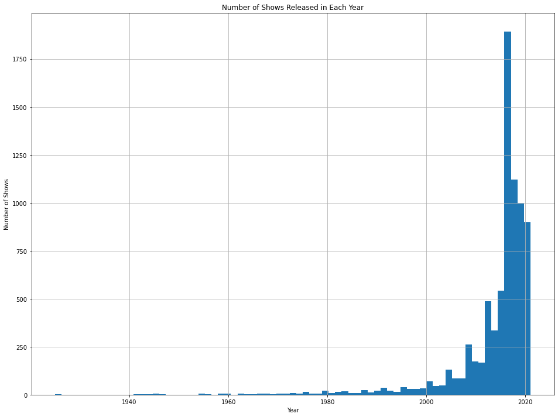

```python
plt.figure(figsize = (16, 12))
netflix_titles['release_year'].hist(bins = 73) # Since we found out that there are 73 unique years
plt.ylabel('Number of Shows')
plt.xlabel('Year')
plt.title('Number of Shows Released in Each Year')
plt.show()
```

From the bar graph, we see that **most shows on Netflix were released quite recently (ie. in the last decade)** and **older shows (especially those before 2000) are rare**. If we include data from older years when finding the most popular topic in each year, the results are likely to be **biased**, as the sample size for older years is very small (near 0 for some years).  
As a rough gauge, we shall only sample shows from years 2000 to 2020, which is when the majority of the shows on Netflix were released. We do not include 2021 as the year is not over yet, so the data for 2021 is incomplete.  
Now, we create function to help us find the most common keywords in each year from 2000 to 2020.

```python
def generate_year_keyword_counts(df, year):
    '''
    This function counts the number of times each keyword appears for show descriptions in a given year from a given dataframe.

    Parameters
    ----------
    df : Pandas DataFrame
        Contains show name, year, list of keywords and each keyword in its own cell in the row
    year : int
        Year to find the most common keywords for

    Returns
    -------
    keyword_year_counts : Pandas DataFrame
        Dataframe of all unique keywords in the year and the number of time each keyword appears in that year

    '''
    df2 = df.loc[df['Year'] == year] # Create a new dataframe so as not to modify the original and only keep shows which are released in the given year
    df2 = df2.drop(columns = ['Show Name', 'Year', 'List of Keywords']) # Remove columns that are not needed
    keyword_year_counts = df2.apply(pd.Series.value_counts)
    keyword_year_counts[str(year)] = keyword_year_counts.sum(axis = 1) # Sum up number of times the keyword appears in a new column, column title is the year
    keyword_year_counts = keyword_year_counts.loc[:,[str(year)]] # Only keep the column with the sum
    if "—" in keyword_year_counts.index:
        keyword_year_counts = keyword_year_counts.drop("—",axis = 0) # Remove "—" that was not removed during processing
    if "–"  in keyword_year_counts.index:
        keyword_year_counts = keyword_year_counts.drop("–",axis = 0) # Note that this is a different dash from the one above (this is the long dash)
    return keyword_year_counts
```

Next, we create a dataframe with the top 10 most common keywords in each year from 2000 to 2020.

```python
years_needed = list(range(2000, 2021)) # Only take years 2000-2020 into consideration

keywords_years_needed  = pd.DataFrame()
for year in years_needed:
    keyword_years = generate_year_keyword_counts(keywords_df, year)
    keyword_years = keyword_years.sort_values(by = [str(year)], ascending = False) # Sort from most to least common keyword
    keywords_years_needed[str(year)] = keyword_years.index.to_series(index = list(range(len(keyword_years.index)))) # Add each year's data to the keywords_years_needed dataframe

keywords_years_needed.head(10)
```

|  | 2000 | 2001 | 2002 | 2003 | 2004 | 2005 | 2006 | 2007 | 2008 | 2009 | ... | 2011 | 2012 | 2013 | 2014 | 2015 | 2016 | 2017 | 2018 | 2019 | 2020 |
| --- | --- | --- | --- | --- | --- | --- | --- | --- | --- | --- | --- | --- | --- | --- | --- | --- | --- | --- | --- | --- | --- |
| 0 | take | young | young | friend | young | love | new | find | life | friend | ... | young | love | young | find | find | life | life | life | life | famili |
| 1 | famili | team | new | find | love | one | young | young | woman | world | ... | friend | new | life | life | new | young | young | young | famili | life |
| 2 | brother | forc | life | three | find | father | two | love | famili | life | ... | live | friend | find | new | life | new | famili | friend | find | friend |
| 3 | last | two | high | love | stori | school | man | world | man | seri | ... | love | take | new | woman | young | find | take | famili | love | young |
| 4 | may | cop | evil | save | student | secret | life | four | becom | love | ... | new | man | famili | world | friend | famili | man | find | new | new |
| 5 | man | take | power | two | one | find | make | tri | two | find | ... | man | two | man | famili | love | two | new | new | friend | world |
| 6 | comedi | daughter | two | turn | famili | come | find | help | make | one | ... | find | one | woman | young | two | world | find | live | world | find |
| 7 | school | new | time | one | return | young | tri | famili | young | young | ... | life | live | take | love | famili | man | woman | man | young | love |
| 8 | day | woman | take | daughter | help | famili | famili | life | live | man | ... | famili | find | friend | live | take | friend | documentari | world | take | seri |
| 9 | dream | world | spi | school | day | turn | woman | seri | find | make | ... | take | tri | love | take | live | live | live | take | seri | take |

10 rows × 21 columns

Putting it all together in a DataFrame, we can see the most common keywords for each year ranked. But this is not the most intuitive way to find the trends in the most popular topics over the years. Now, we will adjust the dataframe to plot a graph of the popular keywords over time.

```python
keywords_over_years  = []
for year in years_needed: # years_needed has been defined earlier
    keyword_years = generate_year_keyword_counts(keywords_df, year)
    keyword_years = keyword_years.sort_values(by = [str(year)], ascending = False)
    keywords_over_years.append(keyword_years.rank(ascending = False, method = 'first')) # Rank keywords in descending order of occurrences, with ranks assigned in the order they appear in in the array

keywords_over_years = pd.concat(keywords_over_years, axis = 1) # Join all the years together
keywords_over_years = keywords_over_years.transpose() # Make the years the rows and the keywords the column
keywords_over_years
```

|  | take | famili | brother | last | may | man | comedi | school | day | dream | ... | hung | hussain | himalaya | his/her | hissrich | hologram | homebound | homegrown | hooki | “mr |
| --- | --- | --- | --- | --- | --- | --- | --- | --- | --- | --- | --- | --- | --- | --- | --- | --- | --- | --- | --- | --- | --- |
| 2000 | 1.0 | 2.0 | 3.0 | 4.0 | 5.0 | 6.0 | 7.0 | 8.0 | 9.0 | 10.0 | ... | NaN | NaN | NaN | NaN | NaN | NaN | NaN | NaN | NaN | NaN |
| 2001 | 6.0 | 405.0 | 318.0 | NaN | NaN | 13.0 | 242.0 | 16.0 | NaN | NaN | ... | NaN | NaN | NaN | NaN | NaN | NaN | NaN | NaN | NaN | NaN |
| 2002 | 9.0 | 47.0 | 360.0 | NaN | 79.0 | 80.0 | NaN | 23.0 | 404.0 | NaN | ... | NaN | NaN | NaN | NaN | NaN | NaN | NaN | NaN | NaN | NaN |
| 2003 | 59.0 | 500.0 | 411.0 | 428.0 | 73.0 | NaN | NaN | 10.0 | 29.0 | 340.0 | ... | NaN | NaN | NaN | NaN | NaN | NaN | NaN | NaN | NaN | NaN |
| 2004 | 89.0 | 7.0 | 91.0 | NaN | 574.0 | NaN | NaN | 36.0 | 10.0 | 402.0 | ... | NaN | NaN | NaN | NaN | NaN | NaN | NaN | NaN | NaN | NaN |
| 2005 | 84.0 | 9.0 | 535.0 | 76.0 | 208.0 | 17.0 | 22.0 | 4.0 | 100.0 | 118.0 | ... | NaN | NaN | NaN | NaN | NaN | NaN | NaN | NaN | NaN | NaN |
| 2006 | 463.0 | 9.0 | 164.0 | NaN | 755.0 | 4.0 | NaN | 20.0 | 35.0 | 110.0 | ... | NaN | NaN | NaN | NaN | NaN | NaN | NaN | NaN | NaN | NaN |
| 2007 | 22.0 | 8.0 | 29.0 | NaN | 755.0 | 14.0 | 50.0 | 26.0 | NaN | 568.0 | ... | NaN | NaN | NaN | NaN | NaN | NaN | NaN | NaN | NaN | NaN |
| 2008 | 35.0 | 3.0 | 54.0 | 249.0 | 1039.0 | 4.0 | 61.0 | 13.0 | 797.0 | 15.0 | ... | NaN | NaN | NaN | NaN | NaN | NaN | NaN | NaN | NaN | NaN |
| 2009 | 22.0 | 11.0 | 44.0 | NaN | 71.0 | 9.0 | 74.0 | 41.0 | 16.0 | 39.0 | ... | NaN | NaN | NaN | NaN | NaN | NaN | NaN | NaN | NaN | NaN |
| 2010 | 13.0 | 9.0 | 56.0 | 373.0 | 173.0 | 5.0 | 201.0 | 26.0 | 1073.0 | 64.0 | ... | NaN | NaN | NaN | NaN | NaN | NaN | NaN | NaN | NaN | NaN |
| 2011 | 10.0 | 9.0 | 350.0 | 67.0 | 79.0 | 6.0 | 66.0 | 18.0 | 901.0 | 77.0 | ... | NaN | NaN | NaN | NaN | NaN | NaN | NaN | NaN | NaN | NaN |
| 2012 | 4.0 | 13.0 | 180.0 | 419.0 | 414.0 | 5.0 | 55.0 | 37.0 | 145.0 | 44.0 | ... | NaN | NaN | NaN | NaN | NaN | NaN | NaN | NaN | NaN | NaN |
| 2013 | 8.0 | 5.0 | 39.0 | 342.0 | 273.0 | 6.0 | 127.0 | 27.0 | 142.0 | 76.0 | ... | NaN | NaN | NaN | NaN | NaN | NaN | NaN | NaN | NaN | NaN |
| 2014 | 10.0 | 6.0 | 44.0 | 512.0 | 263.0 | 12.0 | 178.0 | 55.0 | 113.0 | 203.0 | ... | NaN | NaN | NaN | NaN | NaN | NaN | NaN | NaN | NaN | NaN |
| 2015 | 9.0 | 8.0 | 50.0 | 497.0 | 245.0 | 12.0 | 219.0 | 14.0 | 102.0 | 125.0 | ... | NaN | NaN | NaN | NaN | NaN | NaN | NaN | NaN | NaN | NaN |
| 2016 | 15.0 | 5.0 | 33.0 | 634.0 | 149.0 | 8.0 | 75.0 | 35.0 | 125.0 | 59.0 | ... | NaN | NaN | NaN | NaN | NaN | NaN | NaN | NaN | NaN | NaN |
| 2017 | 4.0 | 3.0 | 64.0 | 346.0 | 290.0 | 5.0 | 96.0 | 70.0 | 122.0 | 125.0 | ... | NaN | NaN | NaN | NaN | NaN | NaN | NaN | NaN | NaN | NaN |
| 2018 | 10.0 | 4.0 | 94.0 | 184.0 | 227.0 | 8.0 | 59.0 | 23.0 | 61.0 | 138.0 | ... | NaN | NaN | NaN | NaN | NaN | NaN | NaN | NaN | NaN | NaN |
| 2019 | 9.0 | 2.0 | 103.0 | 494.0 | 753.0 | 12.0 | 46.0 | 22.0 | 201.0 | 133.0 | ... | NaN | NaN | NaN | NaN | NaN | NaN | NaN | NaN | NaN | NaN |
| 2020 | 10.0 | 1.0 | 204.0 | 3674.0 | 383.0 | 26.0 | 131.0 | 20.0 | 96.0 | 30.0 | ... | 4291.0 | 4294.0 | 4301.0 | 4306.0 | 4307.0 | 4315.0 | 4316.0 | 4318.0 | 4321.0 | 4322.0 |

21 rows × 13863 columns

Now, we plot a line graph tracking the changes in the top 7 most popular keywords/topics over time.

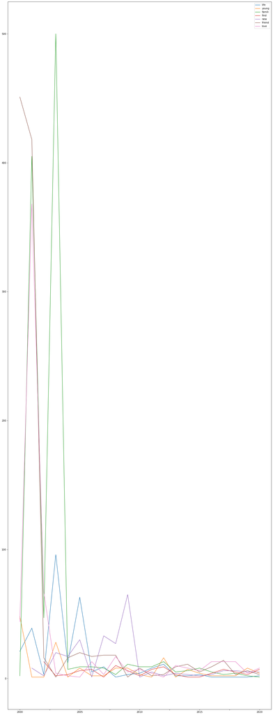

```python
top_keywords = keyword_counts.head(7).index.to_list() # Find top 7 popular keywords of all time (from part 1)
top_keywords_change = keywords_over_years[top_keywords] # Create dataframe with number of occurrences of top 7 popular keywords from 2000 to 2020
top_keywords_change.plot(figsize=(20, 55))
# Note: The graph has deliberately been made long so that we can see the lines in the later years more clearly
```

## 2. Part 1: Finding the pairs of actors or actresses that often work together

First, we create a function to help me find all the actor pairs in a given list of actors. Then, we find all the actor pairs for all shows in `netflix_titles` and find the number of shows each pair has worked on together. This data will be sorted in a dictionary.

```python
# Note: This was adapted from PS4's solution

def get_actor_pairs(actors):
    '''
    Get all pairs from the list "actors"

    Parameters
    ----------
    actors : list
        List of cast (actors and actresses) in one show

    Returns
    -------
    actor_pairs : list of tuples
        List of actor/actress pairs, with each tuple being a pair
    '''
    actor_pairs = []
    for actor_1 in actors:
        for actor_2 in actors:
            if actor_1 > actor_2:  # To prevent duplicate pairs
                actor_pairs.append((actor_1, actor_2))
    return actor_pairs

cast_list = netflix_titles['cast'].to_list() # List of all casts in all shows in netflix_titles
actor_pairs = {} # A dictionary of all actor pairs and the number of shows each pair has worked on together
for cast in cast_list:
    cast = str(cast).split(',')
    for actor_pair in get_actor_pairs(cast):
        if len(actor_pair):
            if actor_pair not in actor_pairs:
                actor_pairs[actor_pair] = 0
            actor_pairs[actor_pair] += 1
```

Finally, we will find the actor pairs that work together the most often and the number of shows they worked together on.

```python
actor_pairs_df = pd.DataFrame.from_dict(actor_pairs, orient = 'index', columns = ['Number of Shows Together'])
actor_pairs_df = actor_pairs_df.sort_values(by = 'Number of Shows Together', ascending = False) # Sort from most shows together to least shows together
actor_pairs_df.head(10)
```

|  | Number of Shows Together |
| --- | --- |
| ( Michael Palin, Eric Idle) | 14 |
| ( Terry Jones, Michael Palin) | 14 |
| ( Terry Jones, Eric Idle) | 14 |
| (Michela Luci, Eric Peterson) | 13 |
| ( Vincent Tong, Alessandro Juliani) | 13 |
| ( Jamie Watson, Eric Peterson) | 13 |
| ( Terry Gilliam, Eric Idle) | 13 |
| (Michela Luci, Jamie Watson) | 13 |
| ( Terry Gilliam, Michael Palin) | 13 |
| ( Terry Jones, Terry Gilliam) | 13 |

## 2. Part 2: Finding the pairs of actors/actresses and directors that often work together

Since we now need to work on data from two columns, we can create a new `DataFrame` with information on the actors and directors (instead of a `list` like just now when we only had to deal with one column).

```python
actor_director_df = pd.DataFrame()
actor_director_df['actors_list'] = netflix_titles['cast']

actor_director_df = actor_director_df['actors_list'].str.split(',', expand = True) # So that each actor has its own cell
actor_director_df['director'] = netflix_titles['director']
actor_director_df = actor_director_df.dropna(subset = ['director']) # Remove shows where the director is missing (ie. NaN)
```

Next, we will create all the actor-director pairs.

```python
pairs_list = [] # Container to store list of actor-director pairs
for index, show in actor_director_df.iterrows():
    show = show.dropna() # Remove shows where the actors are missing
    for member in show: # Member refers to both actors and directors
        if member != actor_director_df.at[index,'director']: # If member is an actor
            member_tuple = (member, actor_director_df.at[index,'director']) # Create a actor-director pair contained in a tuple
            pairs_list.append(member_tuple)
pairs_series = pd.Series(pairs_list, name = 'Number of Shows Together')
pairs_df = pairs_series.value_counts().to_frame() # Convert to dataframe so that it is neater
```

Finally, we will find the actor-director pairs that work together the most often and the number of shows they worked together on.

```python
pairs_df.head(9)
```

|  | Number of Shows Together |
| --- | --- |
| ( Rana Daggubati, S.S. Rajamouli) | 7 |
| ( Tamannaah Bhatia, S.S. Rajamouli) | 7 |
| ( Nassar, S.S. Rajamouli) | 7 |
| ( Sathyaraj, S.S. Rajamouli) | 7 |
| (Prabhas, S.S. Rajamouli) | 7 |
| ( Anushka Shetty, S.S. Rajamouli) | 7 |
| ( Ramya Krishnan, S.S. Rajamouli) | 7 |
| ( Joross Gamboa, Cathy Garcia-Molina) | 6 |
| ( Anupam Kher, David Dhawan) | 6 |

Note: The 10th pair has worked on 5 shows together, but more than 1 pair have worked on 5 shows together, so I chose to include pairs that worked on 6 shows or more only

## 3. Additional Analysis: Recommendation System

By analysing the data, can we identify which shows are most closely related to each other? Using a simple model of counting the number of related features (i.e. actors, keywords etc.), we will match shows to find those that are most related. This is so that **after the user watches one show, the streaming service can automatically recommend similar shows for the user to watch next.**

```python
features_df = pd.DataFrame(columns = ['List of features'], index = list(netflix_titles['title'])) # Create new dataframe to store features
working_df = netflix_titles # Create a working dataframe so that we do not edit the original netflix_titles
working_df = working_df.fillna('') # Remove entries with empty values (ie. NaN)

for index, show in working_df.iterrows():
    keywords_new = processed(show['description'].split()) # Transforms description into individual keywords. Stems words, removes punctuation and stopping words.
    cast_new = show['cast'].split(',')
    genre_new = show['listed_in'].split(',')
    features_list = keywords_new + cast_new + genre_new + [working_df.at[index,'director'], working_df.at[index,'rating'], working_df.at[index,'country']] # Get all the features and put it into a list
    features_df.at[show['title'], 'List of features'] = features_list

features_df.head(10)
```

|  | List of features |
| --- | --- |
| 3% | [futur, elit, inhabit, island, paradis, far, c... |
| 7:19 | [devast, earthquak, hit, mexico, citi, trap, s... |
| 23:59 | [armi, recruit, found, dead, fellow, soldier, ... |
| 9 | [postapocalypt, world, rag-dol, robot, hide, f... |
| 21 | [brilliant, group, student, becom, card-count,... |
| 46 | [genet, professor, experi, treatment, comatos,... |
| 122 | [aw, accid, coupl, admit, grisli, hospit, sepa... |
| 187 | [one, high, school, student, attack, dedic, te... |
| 706 | [doctor, goe, miss, psychiatrist, wife, treat,... |
| 1920 | [architect, wife, move, castl, slate, becom, l... |

Now, we will create a scoring system based on "relatedness". For each feature two shows have in common, one point will be added to their score. The recommendation system will recommend shows from highest scores (most related) to lowest scores (least realated).

```python
score_df = pd.DataFrame(columns = list(netflix_titles['title']), index = list(netflix_titles['title'])) # Dataframe of all show titles against all show titles to keep track of scores
score_df = score_df.fillna(-1) # By default, fill all scores with '-1', which signifies that two shows are not related at all

def find_related_show(title):
    '''
    Given a show from netflix_titles, ranks all other shows in netflix_titles from most related to least related

    Parameters
    ----------
    title : str
        Title of show that you want to find similar shows to

    Raises
    -------
    KeyError
        If show title cannot be found
    TypeError
        If title given is not of type str

    Returns
    -------
    most_related_shows : DataFrame
        DataFrame
    '''
    try:
        for index, show in features_df.iterrows():
            if score_df.at[title, index] == -1:
                score = len(set(features_df.at[title,'List of features']) & set(features_df.at[index,'List of features'])) # Find the number of common features between two shows to find their relatedness score.
                score_df.at[title, index] = score
                score_df.at[index, title] = score
        most_related_shows = score_df[title].sort_values(ascending = False)
        return most_related_shows[1:] # Do not include index 0 as index 0 (the most similar result) is always the given show itself
    except KeyError:
        raise KeyError('Sorry, show title cannot be found. Please try again.')
    except TypeError:
        raise TypeError(f'Expected a str but {type(title)} was given. Please try again.')
```

**Some examples to show how it works:**  
You can *change the show* to find your recommendations based on your own favourite show and you can *change the number of head()* depending on how many show recommendations you wish to receive.

```python
find_related_show('Zozo').head(20)
```

```
West Beirut                          6
Gun City                             5
The Resistance Banker                5
The Endless Trench                   5
Shine Your Eyes                      5
Beasts of No Nation                  5
My Mother's Wound                    5
Street Flow                          5
Kalel, 15                            5
Samantaral                           4
What We Wanted                       4
Cuties                               4
SETHUM AAYIRAM PON                   4
The Angel                            4
Septiembre, un llanto en silencio    4
On My Skin                           4
Weather forecast                     4
Palm Trees in the Snow               4
Harud                                4
Bilu Rakkhosh                        4
Name: Zozo, dtype: int64
```

```python
find_related_show('Busted!').head(10)
```

```
The King: Eternal Monarch    7
Last                         6
Voice                        6
Nightmare High               6
Possessed                    6
Live                         6
The Lies Within              6
Mind Game                    6
My Mister                    6
Abyss                        6
Name: Busted!, dtype: int64
```

### Limitations and Areas of Improvement for 3b3

- We **assume all the features (eg. actor, rating, country) are of equal importance** so we do not weigh the features when calculating the "relatedness" score. In reality, **some features may be more important than others**. For example, a show having the same actor as the given show would be considered a "better" recommendation, than a show that has the same rating as the given show. This is because fans may want to watch shows that their favourite actors star in. On the other hand, many shows may have the same ratings like "PG-13" or "R" so rating is not as important when looking for recommended shows.
  - To improve, we can **create a weighted scoring system**, with some features contributing more to the score than others
- Since **we do not take in any user input or check the user's activity or metrics**, **the recommendations are very general**. To improve, we can also **check the user's watch history** to recommend similar shows (eg. if the users' watch history has a trend of watching shows from a certain actor, the recommendation system can recommend more shows from the same actor).
  - To improve, we can **give the user an option to "sort" the recommendations by the feature that the user thinks is important** (eg. 'Sort by similar actors first' or 'Sort by similar country first')
- The recommendation system **may recommend you shows that you are not supposed to watch, based on the age rating**. For example, it may recommend you a show rated "R" but you are under 17. To go one step further, I could implement the recommendation system for users and check the age of the user (since users are required to enter their birthday when they create a User account). I can then filter the recommendations to only include the age-appropriate ones.
- For the "country" feature, **if there are multiple countries, all the countries for two shows must match exactly to be considered "related"** and to add to their "relatedness" score. Eg. If one show has "South Korea, United States", another show must have "South Korea, United States" too to be considered "related" to the first show. It will not work if it the other show has "United States, South Korea" (in the wrong order) or if the other show only has one country in common like "United States" (partial match). This could be problematic as the two shows have at least one country in common, theoretically they should be considered "related".
  - To fix the problem of countries being in the wrong order, we could use the `split.(')` function on all the entries in the "country" column of the dataframe to split each country into an individual string (eg. 'United States, South Korea' -> 'United States', 'South Korea') and then sort the individual strings alphabetically.
  - To fix the problem of partial matches, we also use `split.(')` on the "country" column in the dataframe. Since each country is now an individual string, we can then compare how many countries two shows have in common and calculate their relatedness score respectively. *An example*:
    - Show 1's countries: 'Brazil', 'France', 'Canada'
    - Show 2's countries: 'France', 'Canada', 'Portugal', 'Mexico'
    - Hence, show 2's relatedness score with regards to show 1 for the "country" feature can be 2/3, since 2/3 countries in show 1 are present in show 2. show 1's relatedness score with regards to 2 can be 1/2, since 2/4 countries in show 2 are present in show 1.
    - However, this would **making the scoring system much more complicated** as Show 1's relatedness score to Show 2 may be different from Show 2's relatedness score to Show 1 (currently, they are the same), hence for simplicity, I did not implement it.

# Conclusion and Reflection

In this project, I have improved on my previous programming of Streaming Service, by creating the classes `User` and `Favourite Playlist` and by creating a search engine. I also conducted some data analysis on Netflix show data.  
**Overall Limitations**

- The data we are working with, `netflix_titles`, is not updated as it was downloaded from Kaggle in May 2021. New shows are constantly being added Netflix, so our data analyses (eg. finding the actor pairs that work together the most) using old data may not be accurate today.
- Some show data is in foreign languages and thus some methods may not work well. For example, searching for shows in foreign languages with keywords may not be successful. We have demonstrated this earlier with Korean.
- In reality, a `User` account may need additional features, such as a password to protect hackers from accessing the account.

**Areas of Improvement or Areas for Futher Development**

- For further development on this project, I can **implement the reccommendation system into the `User` class** and tailor the recommendations to the user's preferences by analysing the user's watch history and favourites playlist. I can also filter out age-inappropriate shows for the user, since the class `User` requires the user to enter his/her birthday.
- It may be helpful to **bring in other datasets (eg. IMDB ratings of Netflix shows) to improve the recommendation system**. For example, the recommendations generated for the user can be sorted by highest rating to lowest rating based on IMDB ratings. This is especially since many recommendations are often tied with the same score, making them hard to differentiate.
- I would also **improve the search method so that it can recognise typos** and **autocorrect** them for the user (eg. "Suss" -> "Seuss"). This is because in real life, many people type very quickly and often make typos. Sometimes, people may also forget how to spell a movie or actor's name.
- The search engine can also be trained to **recognise slang or short-form** (eg. "xmas" -> "Christmas").
- I can also consider presenting my data analysis of word counts in other forms, such as a **word cloud** to display the most popular topics visually.